# Método delta

Juan Pablo Morgan

2024-06-07

## Librerias

```r
library(propagate)
library(car)
library(readr)
library(dplyr)
library(MASS)
library(nortest)
```

## Lectura de la base de datos

```r
Data_HeartDiseases <- read_csv("heart_disease_health_indicators_BRFSS2015.csv")
```

## Método Delta.

Este caso es con la variable HighCol, Diabetes y GenHlth.

```r
# Variables predictorias.
X_1 <- Data_HeartDiseases$HighChol
X_2 <- Data_HeartDiseases$Diabetes
X_3 <- Data_HeartDiseases$GenHlth

# Numero de la muestra.
n <- nrow(Data_HeartDiseases)

# Variable a predecir.
y <- Data_HeartDiseases$HeartDiseaseorAttack

# Coeficiente de correlación de cada una de las Xn respecto a y.
r_n.1 <- cor(X_1, y)
r_n.2 <- cor(X_2, y)
r_n.3 <- cor(X_3, y)
```

El método delta se define como:

$$\frac{\sqrt n[g (r_n) - g(\rho)]}{g'(\rho) (1-\rho^2)} \rightarrow
N(0,1)$$

Con $g(\rho)$ aún desconocida.

Entonces, para encontrar dicha función, tenemos:

$$g'(\rho) \cdot (1-\rho^{2}) = 1$$
Es decir, que tenemos despejando:

$$g(\rho) = \int \frac{1}{1-\rho^{2}}d\rho = arctanh(\rho)$$

Por lo tanto, se define a la función g de forma tal que:

```r
# se define la función g(θ) tal que: g(θ) = arctanh(θ)
g <- function(x) atanh(x)
```

Utilizando la función g encontrada anteriormente, tenemos entonces:
$$\frac{\sqrt n[arctanh(r_n) -
arctanh(\rho)]}{arctanh'(\rho){(1-\rho^2)}} \rightarrow N(0,1)$$

Donde vea que el denominador se cancela debido a que son el mismo valor.

Por lo tanto, observe que tenemos:
$$-z_{1-\frac{\alpha}{2}} < \sqrt n[arctanh(r_n) - arctanh(\rho)]
< z_{1-\frac{\alpha}{2}}$$

## Intervalos de Confianza.

Por lo tanto, tenemos, que el intervalo debe ser:
$$tanh(arctanh(r_n) - \frac{z_{1-\frac{\alpha}{2}}}{\sqrt n}) < \rho
< tanh(arctanh(r_n) + \frac{z_{1-\frac{\alpha}{2}}}{\sqrt n})$$

Donde sabemos que $\alpha = 0.05$, entonces los cuantiles son de la siguiente forma:

```r
alpha <- 0.05
quantil <- qnorm(1-alpha / 2)
```

Entonces, calculamos cada extremo de los intervalos de confianza.

```r
q1.1 <- tanh(g(r_n.1) - (quantil/sqrt(n-3)))
q2.1 <- tanh(g(r_n.1) + (quantil/sqrt(n-3)))
cuantiles_1 <- c(q1.1, q2.1)

q1.2 <- tanh(g(r_n.2) - (quantil/sqrt(n-3)))
q2.2 <- tanh(g(r_n.2) + (quantil/sqrt(n-3)))
cuantiles_2 <- c(q1.2, q2.2)

q1.3 <- tanh(g(r_n.3) - (quantil/sqrt(n-3)))
q2.3 <- tanh(g(r_n.3) + (quantil/sqrt(n-3)))
cuantiles_3 <- c(q1.3, q2.3)
```

Donde $\rho$ sabemos que es:

$$\rho = \frac{Cov(X_n,y)}{\sigma_{X_{n}}\sigma_y}$$

Por lo tanto, el intervalo de confianza generado para cada una de las X, serán los siguientes:

### HighCol

```r
cuantiles_1
```

```
## [1] 0.1769985 0.1845269
```

### Diabetes

```r
cuantiles_2
```

```
## [1] 0.1765041 0.1840340
```

### GenHlth

```r
cuantiles_3
```

```
## [1] 0.2547482 0.2620114
```

## Gráficos

Ahora, para los gráficos utilizaremos boostrap para generarlos correspondientes a cada una de las $X_n$ elegidas.

```r
# Número de replicaciones bootstrap
num_simulaciones <- 25000
bootstrap_samples_1 <- numeric(num_simulaciones)
bootstrap_samples_2 <- numeric(num_simulaciones)
bootstrap_samples_3 <- numeric(num_simulaciones)

for (i in 1:num_simulaciones) {
  indices <- sample(1:n, n, replace = TRUE)
  X_1_boot <- X_1[indices]
  X_2_boot <- X_2[indices]
  X_3_boot <- X_3[indices]
  y_boot <- y[indices]

  bootstrap_samples_1[i] <- cor(X_1_boot, y_boot)
  bootstrap_samples_2[i] <- cor(X_2_boot, y_boot)
  bootstrap_samples_3[i] <- cor(X_3_boot, y_boot)
}
```

Ahora los gráficos, según la variable tomada.

### HighCol

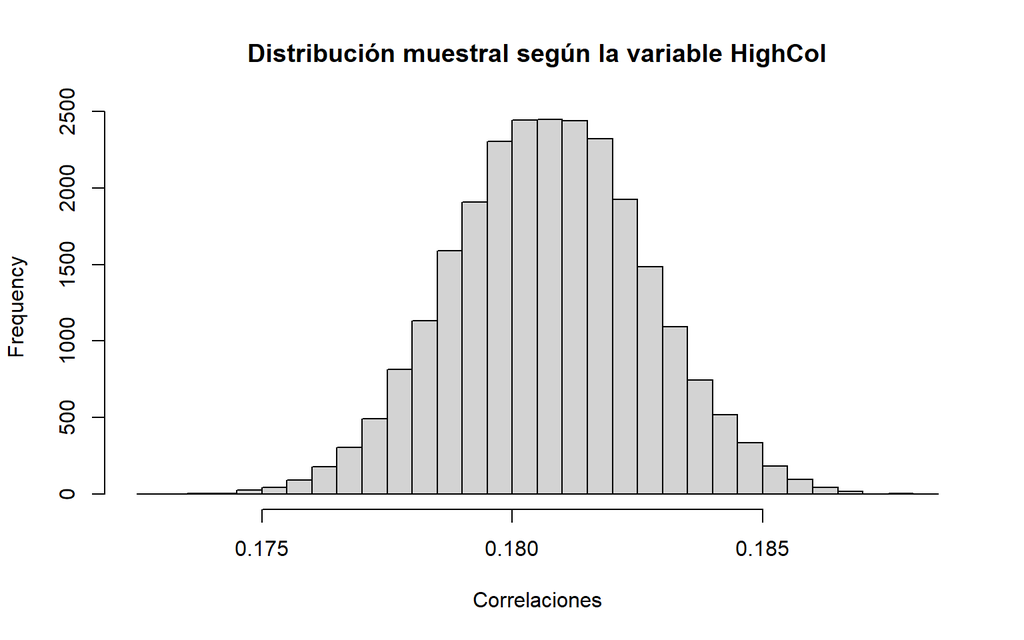

```r
hist(bootstrap_samples_1, breaks = 30, main = "Distribución muestral según la variable HighCol", xlab = "Correlaciones")
```

### Diabetes

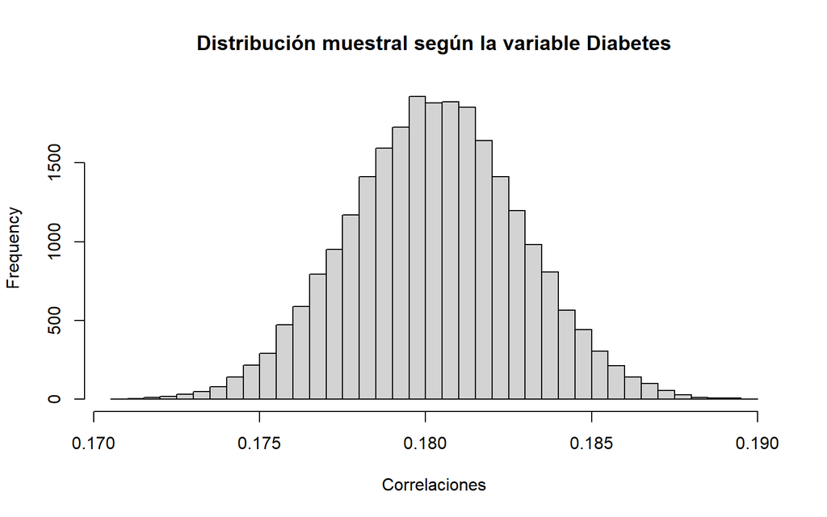

```r
hist(bootstrap_samples_2, breaks = 30, main = "Distribución muestral según la variable Diabetes", xlab = "Correlaciones")
```

### GenHlth

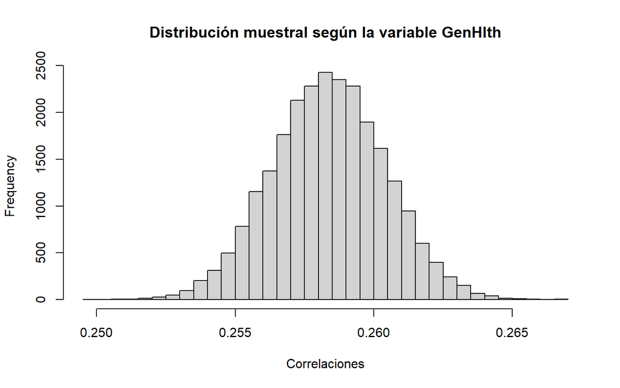

```r
hist(bootstrap_samples_3, breaks = 30, main = "Distribución muestral según la variable GenHlth", xlab = "Correlaciones")
```

## Prueba de normalidad para cada una de las distribuciones anteriores.

Mediante el test de Anderson-Darling, la hipótesis nula es que la distribución es normal, y esta se rechaza en el caso de que $p < 0.05$.

Por lo tanto, al $p > 0.05$ se confirma que todas las distribuciones son normales al no poder rechazarse la hipótesis nula.

### HighCol

```r
ad.test(bootstrap_samples_1)
```

```
##
##  Anderson-Darling normality test
##
## data:  bootstrap_samples_1
## A = 0.57441, p-value = 0.1359
```

### Diabetes

```r
ad.test(bootstrap_samples_2)
```

```
##
##  Anderson-Darling normality test
##
## data:  bootstrap_samples_2
## A = 0.39415, p-value = 0.3741
```

### GenHlth

```r
ad.test(bootstrap_samples_3)
```

```
##
##  Anderson-Darling normality test
##
## data:  bootstrap_samples_3
## A = 0.32107, p-value = 0.5306
```